# Spatial modelling and spatial interpolation

### Spatial modelling and spatial interpolation

\( \newcommand{\Cor}{{\rm Corr}} \)

- Simple ways of interpolation
- Simple statistical models for interpolation
- Geostatistical interpolation
- Deterministic models
- Combined approaches

### Taking a step back

Why do we need models?

- to understand *relations* or *processes*
- to assess (predict, forcast, map) something we do or did not measure *and cannot see*
- to assess the consequence of decisions (scenarios) where we cannot measure

### A sample data set

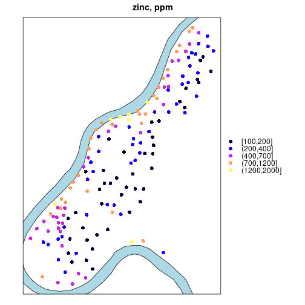

```r
library(sp)
data(meuse.riv)
data(meuse)
coordinates(meuse) = c("x", "y")
meuse.sr = SpatialPolygons(list(Polygons(list(Polygon(meuse.riv)),"meuse.riv")))
spplot(meuse, "zinc", col.regions=bpy.colors(),  main = "zinc, ppm",
       cuts = c(100,200,400,700,1200,2000), key.space = "right",
       sp.layout= list("sp.polygons", meuse.sr, fill = "lightblue")
)
```

### Thiessen “polygons”, 1-NN

```r
library(gstat)
data(meuse)
coordinates(meuse) = ~x+y
data(meuse.grid)
gridded(meuse.grid) = ~x+y

meuse.th = idw(zinc~1, meuse, meuse.grid, nmax = 1)
```

```
## [inverse distance weighted interpolation]
```

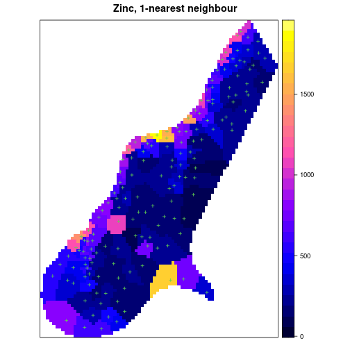

```r
spplot(meuse.th[1],
    col.regions = bpy.colors(30), cuts = 29,
    sp.layout = list("sp.points", meuse, col = 3, cex=.5),
    main = "Zinc, 1-nearest neighbour")
```

### Zinc concentration vs. distance to river

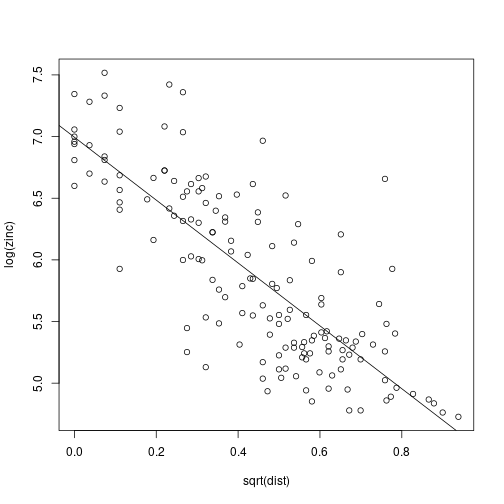

```r
library(sp)
data(meuse)
plot(log(zinc)~sqrt(dist),meuse)
abline(lm(log(zinc)~sqrt(dist),meuse))
```

### Zinc conc. vs. distance to river: map of linear trend

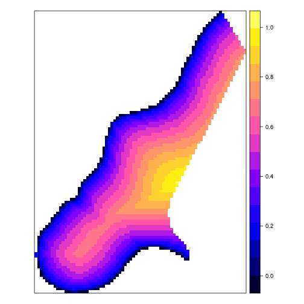

```r
meuse.grid$sqrtdist = sqrt(meuse.grid$dist)
spplot(meuse.grid["sqrtdist"], col.regions = bpy.colors())
```

### Inverse distance weighted interpolation

Uses a **weighted** average: \[\hat{Z}(s_0) = \sum_{i=1}^n \lambda_i Z(s_i)\] with \(s_0 = \{x_0, y_0\}\), or \(s_0 = \{x_0, y_0, \mbox{depth}_0\}\) weights inverse proportional to power \(p\) of distance: \[\lambda_i = \frac{|s_i-s_0|^{-p}}{\sum_{i=1}^n |s_i-s_0|^{-p}}\]

- power \(p\): tuning parameter
- if for some \(i\), \(|s_i-s_0| = 0\), then \(\lambda_i = 1\) and other weights become zero
- \(\Rightarrow\) **exact** interpolator

### Effect of power \(p\)

```r
library(sp)
set.seed(13531)
pts = data.frame(x = 1:10, y = rep(0,10), z = rnorm(10)*3 + 6)
coordinates(pts) = ~x+y
xpts = 0:1100 / 100
grd = data.frame(x = xpts, y = rep(0, length(xpts)))
gridded(grd) = ~x+y
```

```r
library(gstat)
plot(z ~ x, as(pts, "data.frame"), xlab ='location', ylab = 'attribute value')
lines(xpts, idw(z~1, pts, grd, idp = 2)$var1.pred)
```

```
## [inverse distance weighted interpolation]
```

```r
lines(xpts, idw(z~1, pts, grd, idp = 5)$var1.pred, col = 'darkgreen')
```

```
## [inverse distance weighted interpolation]
```

```r
lines(xpts, idw(z~1, pts, grd, idp = .5)$var1.pred, col = 'red')
```

```
## [inverse distance weighted interpolation]
```

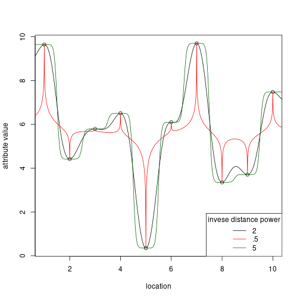

```r
legend("bottomright", c("2", ".5", "5"), lty = 1,
    col=c("black", "red", "darkgreen"), title = "invese distance power")
```

### Simple statistical models for interpolation

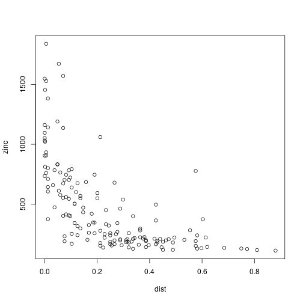

```r
library(sp)
data(meuse)
plot(zinc~dist, meuse)
```

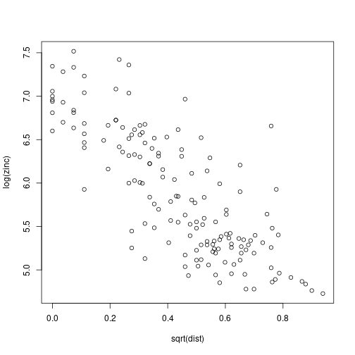

```r
plot(log(zinc)~sqrt(dist), meuse)
```

### Time series versus spatial data

Differences:

- spatial data live in 2 (or 3) dimensions
- there's no past and future
- there's no simple conditional independence (AR) Correspondences
- nearby observations are more alike (auto-correlation)
- we can form moving averages
- coordinate reference systems are a bit like time zones and DST

### What information do we have?

- We have measurements \(Z(x)\), with \(x\) two-dimensional (location on the map)
- we have \(x\) and \(y\)
- we may have land use data
- we may have soil type or geological data
- we may have remote sensing imagery
- we may have all kinds of relevant information, related to processes that cause (or result from) \(Z(x)\)
- we have google maps

*We don't want to ignore anything important*

### Regression or correlation?

(Correlation between two different variables, no auto-correlation:)

```r
n = 500
x = rnorm(n)
y = rnorm(n)
R = matrix(c(1,0,0,1),2,2)
R
```

```
##      [,1] [,2]
## [1,]    1    0
## [2,]    0    1
```

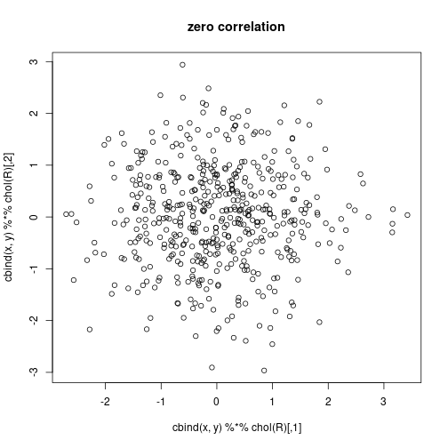

```r
plot(cbind(x,y) %*% chol(R))
title("zero correlation")
```

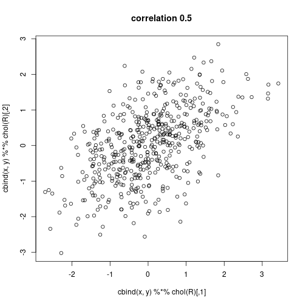

```r
R[2,1] = R[1,2] = 0.5
plot(cbind(x,y) %*% chol(R))
title("correlation 0.5")
```

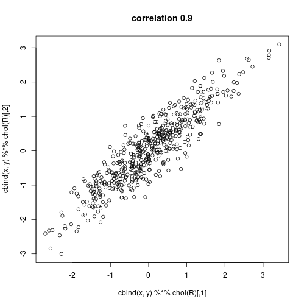

```r
R[2,1] = R[1,2] = 0.9
plot(cbind(x,y) %*% chol(R))
title("correlation 0.9")
```

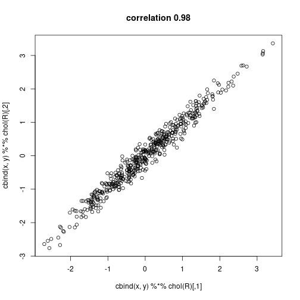

```r
R[2,1] = R[1,2] = 0.98
plot(cbind(x,y) %*% chol(R))
title("correlation 0.98")
```

### Correlation vs. regression:

Correspondences:

- both are in the “classic statistics” book, and may involve hypothesis testing
- both deal with *two* continuous variables
- both look at (first order) *linear* relations
- when correlation is significant, the regression *slope* is significant Differences:
- Regression distinguishes \(y\) from \(x\): \(y\) depends on \(x\), not reverse;
- the line \(y=ax+b\) is *not* equal to the line \(x = cy + d\)
- Correlation is symmetric: \(\Cor(x,y)=\Cor(y,x)\)
- Correlation coefficient is unitless and within \([-1,1]\), regression coeficients have data units
- Regression is concerned with *prediction* of \(y\) from \(x\).

### The power of regression models for spatial prediction

… is hard to overestimate. Regression and correlation are the fork and knife of statistics.

- linear models have endless application: polynomials, interactions, nested effects, ANOVA/ANCOVA models, hypothesis testing, lack of fit testing, …
- predictors can be transformed non-linearly
- linear models can be generalized: logistic regression, Poisson regression, …, to cope with discrete data (0/1 data, counts, log-normal)
- many derived techniques solve one particular issue in regression, e.g.:
  - ridge regression solves collinearity (extreme correlation among predictors)
  - stepwise regression automatically selects “best” models among many candidates
  - classification and regression trees

# Why is regression difficult in spatial problems?

Regression models assume independent observations. Spatial data are always to some degree spatially correlated.

This does not mean we should discard regression, but rather think about

- to which extent is an outcome dependent on independence?
- to which extent is regression *robust* agains a violated assumption of independent observations?
- to which extent *is* the assumption violated? (how strong is the correlation)

### What is spatial correlation?

Waldo Tobler's first law in geography:

Everything is related to everything else, but near things are more related than distant things.“ [Tobler, 1970, p.236]

TOBLER, W. R. (1970). "A computer model simulation of urban growth in the Detroit region”. Economic Geography, 46(2): 234-240.

*But how then is “being related” expressed?*